# Apply ML algorithms

- Linear Regression

```python
import numpy as np
import pandas as pd
import matplotlib.pyplot as plt
import seaborn as sns
```

```python
df=pd.read_csv('E:\AQI-Project-master\AQI-Data\Real Data\Real_Combine.csv')
```

```python
df.head()
```

|  | T | TM | Tm | SLP | H | VV | V | VM | PM 2.5 |
| --- | --- | --- | --- | --- | --- | --- | --- | --- | --- |
| 0 | 7.4 | 9.8 | 4.8 | 1017.6 | 93.0 | 0.5 | 4.3 | 9.4 | 219.720833 |
| 1 | 7.8 | 12.7 | 4.4 | 1018.5 | 87.0 | 0.6 | 4.4 | 11.1 | 182.187500 |
| 2 | 6.7 | 13.4 | 2.4 | 1019.4 | 82.0 | 0.6 | 4.8 | 11.1 | 154.037500 |
| 3 | 8.6 | 15.5 | 3.3 | 1018.7 | 72.0 | 0.8 | 8.1 | 20.6 | 223.208333 |
| 4 | 12.4 | 20.9 | 4.4 | 1017.3 | 61.0 | 1.3 | 8.7 | 22.2 | 200.645833 |

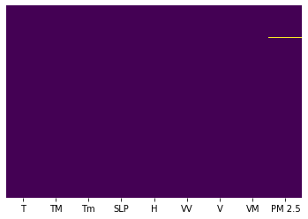

```python
#check for null values

sns.heatmap(df.isnull(),yticklabels=False,cbar=False,cmap='viridis')
```

```python
df=df.dropna()
```

```python
X=df.iloc[:,:-1] ## independent features
y=df.iloc[:,-1] ##dependent features
```

```python
## check null values
X.isnull()
```

|  | T | TM | Tm | SLP | H | VV | V | VM |
| --- | --- | --- | --- | --- | --- | --- | --- | --- |
| 0 | False | False | False | False | False | False | False | False |
| 1 | False | False | False | False | False | False | False | False |
| 2 | False | False | False | False | False | False | False | False |
| 3 | False | False | False | False | False | False | False | False |
| 4 | False | False | False | False | False | False | False | False |
| ... | ... | ... | ... | ... | ... | ... | ... | ... |
| 1088 | False | False | False | False | False | False | False | False |
| 1089 | False | False | False | False | False | False | False | False |
| 1090 | False | False | False | False | False | False | False | False |
| 1091 | False | False | False | False | False | False | False | False |
| 1092 | False | False | False | False | False | False | False | False |

1092 rows × 8 columns

```python
y.isnull()
```

```
0       False
1       False
2       False
3       False
4       False
        ...
1088    False
1089    False
1090    False
1091    False
1092    False
Name: PM 2.5, Length: 1092, dtype: bool
```

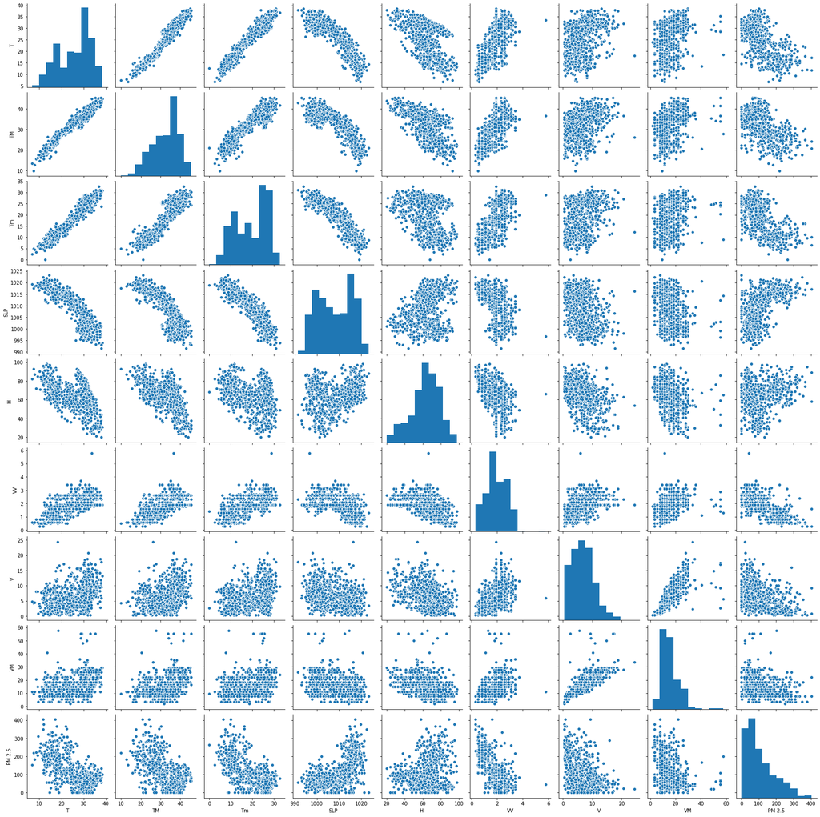

```python
sns.pairplot(df)
```

```python
df.corr()
```

|  | T | TM | Tm | SLP | H | VV | V | VM | PM 2.5 |
| --- | --- | --- | --- | --- | --- | --- | --- | --- | --- |
| T | 1.000000 | 0.967536 | 0.953719 | -0.881409 | -0.509299 | 0.640792 | 0.301994 | 0.287738 | -0.631462 |
| TM | 0.967536 | 1.000000 | 0.892031 | -0.822958 | -0.586681 | 0.606945 | 0.292949 | 0.297011 | -0.568409 |
| Tm | 0.953719 | 0.892031 | 1.000000 | -0.917518 | -0.287357 | 0.577240 | 0.296225 | 0.266782 | -0.673824 |
| SLP | -0.881409 | -0.822958 | -0.917518 | 1.000000 | 0.240256 | -0.517915 | -0.329838 | -0.310704 | 0.623187 |
| H | -0.509299 | -0.586681 | -0.287357 | 0.240256 | 1.000000 | -0.465374 | -0.380575 | -0.362177 | 0.138005 |
| VV | 0.640792 | 0.606945 | 0.577240 | -0.517915 | -0.465374 | 1.000000 | 0.376873 | 0.342442 | -0.573941 |
| V | 0.301994 | 0.292949 | 0.296225 | -0.329838 | -0.380575 | 0.376873 | 1.000000 | 0.775655 | -0.268530 |
| VM | 0.287738 | 0.297011 | 0.266782 | -0.310704 | -0.362177 | 0.342442 | 0.775655 | 1.000000 | -0.215854 |
| PM 2.5 | -0.631462 | -0.568409 | -0.673824 | 0.623187 | 0.138005 | -0.573941 | -0.268530 | -0.215854 | 1.000000 |

#### Correlation Matrix with Heatmap

Correlation states how the features are related to each other or the target variable.

Correlation can be positive (increase in one value of feature increases the value of the target variable) or negative (increase in one value of feature decreases the value of the target variable)

Heatmap makes it easy to identify which features are most related to the target variable, we will plot heatmap of correlated features using the seaborn library.

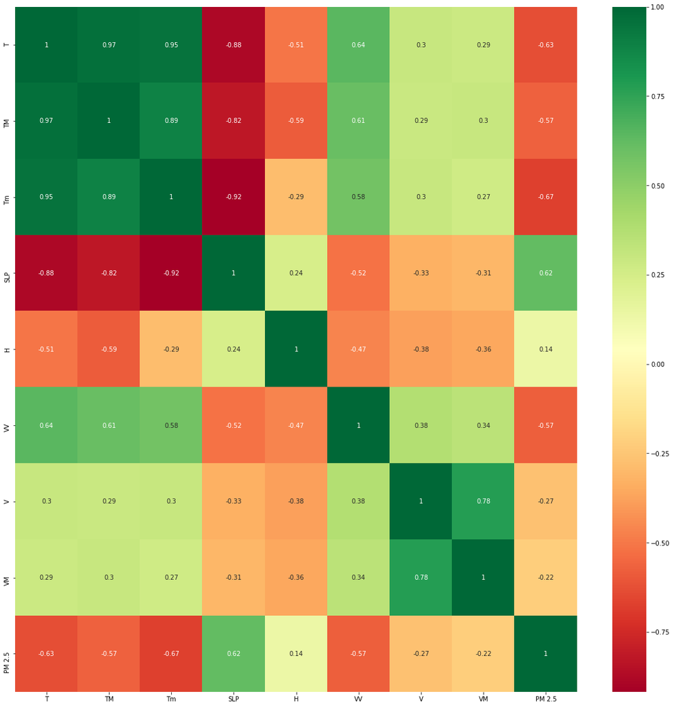

```python
import seaborn as sns
##get correlations of each features in database
corrmat = df.corr()
top_corr_features = corrmat.index
plt.figure(figsize=(20,20))
#Plot heatmap
g=sns.heatmap(df[top_corr_features].corr(),annot=True,cmap="RdYlGn")
```

```python
corrmat.index
```

```
Index(['T', 'TM', 'Tm', 'SLP', 'H', 'VV', 'V', 'VM', 'PM 2.5'], dtype='object')
```

#### Feature Importance

You can get the feature importance of each feature of your dataset by using the feature importance property of the model.

Feature importance gives you a score for each feature of your data, the higher the score more important or relevant is the feature towards your output variable.

```python
from sklearn.ensemble import ExtraTreesRegressor
import matplotlib.pyplot as plt
model = ExtraTreesRegressor()
model.fit(X,y)
```

```
ExtraTreesRegressor(bootstrap=False, ccp_alpha=0.0, criterion='mse',
                    max_depth=None, max_features='auto', max_leaf_nodes=None,
                    max_samples=None, min_impurity_decrease=0.0,
                    min_impurity_split=None, min_samples_leaf=1,
                    min_samples_split=2, min_weight_fraction_leaf=0.0,
                    n_estimators=100, n_jobs=None, oob_score=False,
                    random_state=None, verbose=0, warm_start=False)
```

```python
X.head()
```

|  | T | TM | Tm | SLP | H | VV | V | VM |
| --- | --- | --- | --- | --- | --- | --- | --- | --- |
| 0 | 7.4 | 9.8 | 4.8 | 1017.6 | 93.0 | 0.5 | 4.3 | 9.4 |
| 1 | 7.8 | 12.7 | 4.4 | 1018.5 | 87.0 | 0.6 | 4.4 | 11.1 |
| 2 | 6.7 | 13.4 | 2.4 | 1019.4 | 82.0 | 0.6 | 4.8 | 11.1 |
| 3 | 8.6 | 15.5 | 3.3 | 1018.7 | 72.0 | 0.8 | 8.1 | 20.6 |
| 4 | 12.4 | 20.9 | 4.4 | 1017.3 | 61.0 | 1.3 | 8.7 | 22.2 |

```python
print(model.feature_importances_)
```

```
[0.1439985  0.1100837  0.22311269 0.14857368 0.09097563 0.18738622
 0.0518397  0.04402987]
```

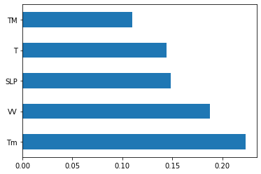

```python
##Plot graph of feature importance for better visualization
feat_importance = pd.Series(model.feature_importances_,index=X.columns)
feat_importance.nlargest(5).plot(kind='barh')
plt.show()
```

#### Linear Regression

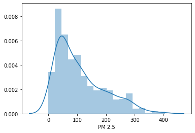

```python
sns.distplot(y)
```

#### Train Test Split

```python
from sklearn.model_selection import train_test_split
X_train,X_test,y_train,y_test = train_test_split(X, y, test_size=0.3, random_state=0)
```

```python
from sklearn.linear_model import LinearRegression
```

```python
regressor = LinearRegression()
regressor.fit(X_train,y_train)
```

```
LinearRegression(copy_X=True, fit_intercept=True, n_jobs=None, normalize=False)
```

```python
regressor.coef_
```

```
array([ -2.69090829,   0.46219975,  -3.86705184,  -0.04494855,
        -1.21193616, -40.11490762,  -2.53563257,   0.56148181])
```

```python
regressor.intercept_
```

```
448.11616967588736
```

```python
print("Coefficient of determination on R^2<-- train set: {}".format(regressor.score(X_train,y_train)))
```

```
Coefficient of determination on R^2<-- train set: 0.551516808175875
```

```python
print("Coefficient of determination on R^2<-- test set: {}".format(regressor.score(X_test,y_test)))
```

```
Coefficient of determination on R^2<-- test set: 0.48525331308567915
```

```python
from sklearn.model_selection import cross_val_score
score=cross_val_score(regressor,X,y,cv=5)
```

```python
score.mean()
```

```
0.4710569304807392
```

#### Model Evaluation

```python
coeff_df=pd.DataFrame(regressor.coef_,X.columns,columns=['Coefficient'])
coeff_df
```

[output not shown]

##### Interpreting the coefficients:

- Holding all other features fixed, a 1 unit increase in T is associated with an decrease of 2.690 in AQI PM2.5 .
- Holding all other features fixed, a 1 unit increase in TM is associated with an increase of 0.46 in AQI PM 2.5 .

```python
prediction=regressor.predict(X_test)
```

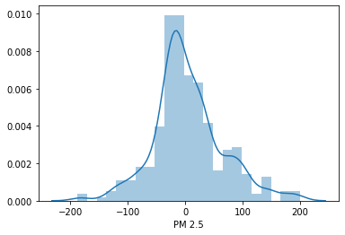

```python
sns.distplot(y_test-prediction)
```

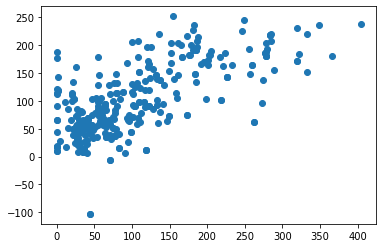

```python
plt.scatter(y_test,prediction)
```

##### Regression Evaluation Metrics

Mean Squared Error (MSE) is the mean of the squared errors:

$$\frac 1n\sum_{i=1}^n(y_i-\hat{y}_i)^2$$

Root Mean Squared Error (RMSE) is the square root of the mean of the squared errors:

$$\sqrt{\frac 1n\sum_{i=1}^n(y_i-\hat{y}_i)^2}$$

Comparing these metrics:

MAE is the easiest to understand, because it's the average error. MSE is more popular than MAE, because MSE "punishes" larger errors, which tends to be useful in the real world. RMSE is even more popular than MSE, because RMSE is interpretable in the "y" units. All of these are loss functions, because we want to minimize them.

```python
from sklearn import metrics
```

```python
print('MAE:',metrics.mean_absolute_error(y_test,prediction))
print('MSE:',metrics.mean_squared_error(y_test,prediction))
print('RMSE:',np.sqrt(metrics.mean_squared_error(y_test,prediction)))
```

```
MAE: 44.836241266286365
MSE: 3687.5430309324165
RMSE: 60.72514331751236
```

```python
import pickle
```

```python
#open a file, where you ant to store data
file = open('regression_model.pkl','wb')

#dump information to that file
pickle.dump(regressor, file)
```